# 03 — Factos estilizados da Walmart (WMT): testes estatísticos e GJR-GARCH

Neste notebook testamos, para a **Walmart (WMT)**, os seis factos estilizados pedidos no enunciado, nas frequências **diária, semanal e mensal**:

1. Pouca ou nenhuma autocorrelação nos retornos;
2. Distribuição não normal e caudas pesadas (sobretudo na frequência diária);
3. Assimetria da distribuição (possível *skewness* negativa);
4. *Clustering* de volatilidade (retornos absolutos e ao quadrado);
5. Efeito alavanca (a volatilidade reage mais a choques negativos do que a positivos);
6. Não-normalidade condicional (resíduos padronizados de um modelo de volatilidade).

O **SPY** (ETF que replica o S&P 500) é usado como termo de comparação.

**Regra de decisão:** nível de significância de 5% → se o *p-value* < 0.05 rejeitamos a hipótese nula (H0). O enunciado diz para **não assumir** que todos os factos se verificam — por isso, para cada facto, olhamos para os números e decidimos.

Os gráficos são guardados em `../graficos/` e as tabelas em `../resultados/`.

```python
import os
import numpy as np
import pandas as pd
import matplotlib.pyplot as plt
from scipy import stats
from statsmodels.graphics.tsaplots import plot_acf
from statsmodels.tsa.stattools import acf
from statsmodels.stats.diagnostic import acorr_ljungbox, het_arch
from arch import arch_model
from IPython.display import display

import warnings
warnings.filterwarnings('ignore')   # esconder avisos de versões das bibliotecas (não mudam os resultados)

plt.rcParams['figure.figsize'] = (10, 4)
pd.set_option('display.max_columns', 20)
pd.set_option('display.width', 200)

# Pastas onde vamos guardar os gráficos e as tabelas
os.makedirs('../graficos', exist_ok=True)
os.makedirs('../resultados', exist_ok=True)

ALFA = 0.05   # nível de significância usado em todos os testes
```

## 1. Carregar os retornos logarítmicos

Os retornos foram calculados no notebook `01` a partir dos preços **ajustados** (*Adj Close*), que já incorporam dividendos e *splits* (por exemplo, o *split* 3-para-1 da Walmart em fevereiro de 2024 não aparece como uma queda falsa de -67%).

- **Diários:** $r_t = \ln(P_t) - \ln(P_{t-1})$
- **Semanais e mensais:** usando o último preço de cada semana (sexta-feira) / de cada mês.

```python
ret_d = pd.read_csv('data/retornos_diarios.csv', index_col=0, parse_dates=True)
ret_s = pd.read_csv('data/retornos_semanais.csv', index_col=0, parse_dates=True)
ret_m = pd.read_csv('data/retornos_mensais.csv', index_col=0, parse_dates=True)

# Dicionário com as 3 frequências -> permite fazer ciclos (for) em vez de repetir código 3 vezes
frequencias = {
    'Daily': ret_d,
    'Weekly': ret_s,
    'Monthly': ret_m,
}

# Nº de períodos num ano (para anualizar)
periodos_por_ano = {'Daily': 252, 'Weekly': 52, 'Monthly': 12}

ativos = ['WMT', 'SPY']   # WMT = ação escolhida | SPY = referência de mercado

for freq, tabela in frequencias.items():
    r = tabela['WMT'].dropna()
    print(f'{freq:8s}: {len(r):5d} observações, de {r.index.min().date()} a {r.index.max().date()}')
```

```
Daily   :  4202 observações, de 2010-01-05 a 2026-09-18
Weekly  :   871 observações, de 2010-01-15 a 2026-09-18
Monthly :   199 observações, de 2010-02-28 a 2026-08-31
```

**Verificação:** com retornos **logarítmicos**, o retorno de um mês é igual à soma dos retornos diários desse mês. Assim confirmamos que as duas formas de calcular (preço de fim de período vs. soma dos diários) dão o mesmo resultado.

```python
# Somar os retornos diários dentro de cada mês / semana
soma_mensal = ret_d['WMT'].resample('ME').sum()
soma_semanal = ret_d['WMT'].resample('W-FRI').sum()

# Juntar lado a lado e retirar linhas incompletas
comp_m = pd.DataFrame({'preco_fim_mes': ret_m['WMT'], 'soma_diarios': soma_mensal}).dropna()
comp_s = pd.DataFrame({'preco_fim_semana': ret_s['WMT'], 'soma_diarios': soma_semanal}).dropna()

print('Maior diferença (mensal): ', (comp_m['preco_fim_mes'] - comp_m['soma_diarios']).abs().max())
print('Maior diferença (semanal):', (comp_s['preco_fim_semana'] - comp_s['soma_diarios']).abs().max())
```

```
Maior diferença (mensal):  1.1032841307212493e-15
Maior diferença (semanal): 8.014422459012849e-16
```

## 2. Estatísticas descritivas (WMT e SPY, 3 frequências)

A curtose apresentada é o **excesso de curtose** (curtose − 3): uma distribuição normal tem valor 0.

```python
def estatisticas_descritivas(r, n_periodos):
    # Calcula as estatísticas descritivas de uma série de retornos log
    r = r.dropna()
    return {
        'N': len(r),
        'Mean': r.mean(),
        'Std. dev.': r.std(),
        'Min': r.min(),
        'Max': r.max(),
        'Skewness': stats.skew(r),
        'Excess kurtosis': stats.kurtosis(r),          # fisher=True por defeito -> normal = 0
        'Ann. mean': r.mean() * n_periodos,              # média anualizada
        'Ann. volatility': r.std() * np.sqrt(n_periodos) # volatilidade anualizada (regra da raiz do tempo)
    }


linhas = []
for ativo in ativos:
    for freq, tabela in frequencias.items():
        linha = estatisticas_descritivas(tabela[ativo], periodos_por_ano[freq])
        linha['Asset'] = ativo
        linha['Frequency'] = freq
        linhas.append(linha)

tab_descritivas = pd.DataFrame(linhas).set_index(['Asset', 'Frequency'])
display(tab_descritivas.round(4))
```

| Asset | Frequency | N | Mean | Std. dev. | Min | Max | Skewness | Excess kurtosis | Ann. mean | Ann. volatility |
| --- | --- | --- | --- | --- | --- | --- | --- | --- | --- | --- |
| WMT | Daily | 4202 | 0.0005 | 0.0126 | -0.1208 | 0.1107 | -0.2546 | 14.3211 | 0.1268 | 0.1999 |
|  | Weekly | 871 | 0.0024 | 0.0273 | -0.2167 | 0.1093 | -0.8532 | 6.6738 | 0.1273 | 0.1970 |
|  | Monthly | 199 | 0.0106 | 0.0517 | -0.1698 | 0.1378 | -0.3603 | 0.8379 | 0.1274 | 0.1791 |
| SPY | Daily | 4202 | 0.0005 | 0.0108 | -0.1159 | 0.0999 | -0.5549 | 12.4025 | 0.1320 | 0.1709 |
|  | Weekly | 871 | 0.0025 | 0.0224 | -0.1572 | 0.1141 | -0.7400 | 5.8279 | 0.1307 | 0.1617 |
|  | Monthly | 199 | 0.0114 | 0.0413 | -0.1334 | 0.1195 | -0.4909 | 0.6703 | 0.1362 | 0.1432 |

## 3. Facto 1 — Pouca ou nenhuma autocorrelação nos retornos

- **Gráfico ACF:** barras dentro da banda azul (95%) → autocorrelação não significativa.
- **Teste de Ljung-Box:** H0 = "não há autocorrelação até ao lag *m*". *p-value* < 0.05 → rejeitamos H0.

Nota: com milhares de observações diárias, até autocorrelações minúsculas ficam "significativas". Por isso também olhamos para o **tamanho** das autocorrelações.

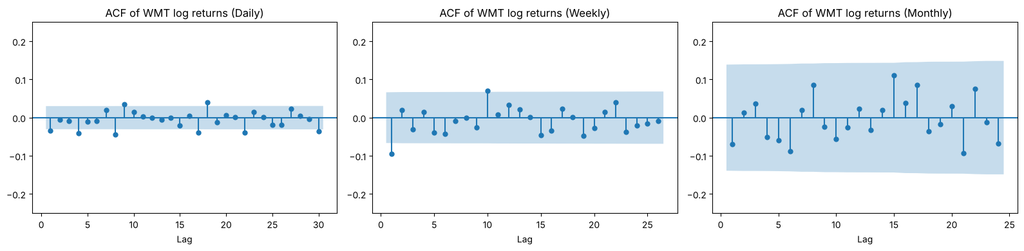

```python
# Nº de lags a mostrar nos gráficos e a usar nos testes, para cada frequência
lags_grafico = {'Daily': 30, 'Weekly': 26, 'Monthly': 24}
lags_teste = {'Daily': [5, 10, 20], 'Weekly': [4, 8, 12], 'Monthly': [3, 6, 12]}

fig, axes = plt.subplots(1, 3, figsize=(16, 4))
for i, (freq, tabela) in enumerate(frequencias.items()):
    plot_acf(tabela['WMT'].dropna(), lags=lags_grafico[freq], ax=axes[i], zero=False, alpha=0.05)
    axes[i].set_title(f'ACF of WMT log returns ({freq})')
    axes[i].set_xlabel('Lag')
    axes[i].set_ylim(-0.25, 0.25)
plt.tight_layout()
plt.savefig('../graficos/03_acf_retornos_wmt.png', dpi=150)
plt.show()
```

```python
def tabela_ljung_box(serie, lags, ativo, freq, nome_serie):
    # Corre o teste de Ljung-Box para vários lags e devolve uma lista de linhas (dicionários)
    resultado = acorr_ljungbox(serie.dropna(), lags=lags)
    linhas = []
    for lag in lags:
        linhas.append({
            'Asset': ativo,
            'Frequency': freq,
            'Series': nome_serie,
            'Lag': lag,
            'Q stat': resultado.loc[lag, 'lb_stat'],
            'p-value': resultado.loc[lag, 'lb_pvalue'],
        })
    return linhas


linhas = []
for ativo in ativos:
    for freq, tabela in frequencias.items():
        linhas += tabela_ljung_box(tabela[ativo], lags_teste[freq], ativo, freq, 'r')

tab_lb_retornos = pd.DataFrame(linhas)
tab_lb_retornos['Reject H0 (5%)'] = tab_lb_retornos['p-value'] < ALFA
display(tab_lb_retornos.round(4))
```

|  | Asset | Frequency | Series | Lag | Q stat | p-value | Reject H0 (5%) |
| --- | --- | --- | --- | --- | --- | --- | --- |
| 0 | WMT | Daily | r | 5 | 13.1086 | 0.0224 | True |
| 1 | WMT | Daily | r | 10 | 29.2625 | 0.0011 | True |
| 2 | WMT | Daily | r | 20 | 45.1819 | 0.0010 | True |
| 3 | WMT | Weekly | r | 4 | 9.2443 | 0.0553 | False |
| 4 | WMT | Weekly | r | 8 | 12.2448 | 0.1406 | False |
| 5 | WMT | Weekly | r | 12 | 18.1953 | 0.1099 | False |
| 6 | WMT | Monthly | r | 3 | 1.2870 | 0.7322 | False |
| 7 | WMT | Monthly | r | 6 | 4.1358 | 0.6583 | False |
| 8 | WMT | Monthly | r | 12 | 6.7871 | 0.8714 | False |
| 9 | SPY | Daily | r | 5 | 70.9275 | 0.0000 | True |
| 10 | SPY | Daily | r | 10 | 168.1952 | 0.0000 | True |
| 11 | SPY | Daily | r | 20 | 203.8557 | 0.0000 | True |
| 12 | SPY | Weekly | r | 4 | 11.0526 | 0.0260 | True |
| 13 | SPY | Weekly | r | 8 | 17.6772 | 0.0238 | True |
| 14 | SPY | Weekly | r | 12 | 22.7410 | 0.0300 | True |
| 15 | SPY | Monthly | r | 3 | 6.0975 | 0.1070 | False |
| 16 | SPY | Monthly | r | 6 | 7.8724 | 0.2476 | False |
| 17 | SPY | Monthly | r | 12 | 12.7935 | 0.3842 | False |

```python
# Qual é o TAMANHO das autocorrelações (lags 1 a 5)?
linhas = []
for ativo in ativos:
    for freq, tabela in frequencias.items():
        r = tabela[ativo].dropna()
        valores = acf(r, nlags=5)
        linha = {'Asset': ativo, 'Frequency': freq}
        for lag in range(1, 6):
            linha[f'lag {lag}'] = valores[lag]
        linha['95% band (±1.96/√N)'] = 1.96 / np.sqrt(len(r))
        linhas.append(linha)

tab_acf = pd.DataFrame(linhas).set_index(['Asset', 'Frequency'])
display(tab_acf.round(4))
```

| Asset | Frequency | lag 1 | lag 2 | lag 3 | lag 4 | lag 5 | 95% band (±1.96/√N) |
| --- | --- | --- | --- | --- | --- | --- | --- |
| WMT | Daily | -0.0344 | -0.0061 | -0.0087 | -0.0413 | -0.0106 | 0.0302 |
|  | Weekly | -0.0953 | 0.0193 | -0.0301 | 0.0143 | -0.0395 | 0.0664 |
|  | Monthly | -0.0698 | 0.0139 | 0.0360 | -0.0503 | -0.0593 | 0.1389 |
| SPY | Daily | -0.1003 | 0.0615 | -0.0376 | -0.0401 | 0.0014 | 0.0302 |
|  | Weekly | -0.0889 | 0.0365 | -0.0149 | -0.0563 | -0.0641 | 0.0664 |
|  | Monthly | -0.1253 | -0.1169 | 0.0271 | -0.0580 | 0.0009 | 0.1389 |

**Leitura dos resultados (Facto 1):**

- **Mensal e semanal (WMT):** o Ljung-Box **não rejeita** H0 → não há evidência de autocorrelação. O facto verifica-se.
- **Diário (WMT):** o Ljung-Box rejeita H0, mas as autocorrelações são muito pequenas (|ρ| < 0.05, quase todas negativas). Com ~4 200 observações a banda de 95% é apenas ±0.03, por isso valores minúsculos ficam "significativos". Economicamente, conhecer o retorno de hoje praticamente não ajuda a prever o de amanhã.
- Além disso, o teste de Ljung-Box assume variância constante; com *clustering* de volatilidade (Facto 4) tende a rejeitar demasiadas vezes. Na secção 8 repetimos o teste nos **resíduos padronizados do GARCH** e aí a autocorrelação deixa de ser significativa.
- O **SPY** mostra autocorrelação diária negativa mais forte (lag 1 ≈ −0.1), típica de índices em períodos de stress (efeitos de reversão).

**Conclusão:** o facto é suportado na prática para a WMT — a autocorrelação nos níveis dos retornos é pequena ou inexistente.

## 4. Facto 2 — Distribuição não normal e caudas pesadas

- **Q-Q plot:** se os retornos fossem normais, os pontos ficariam em cima da linha vermelha.
- **Jarque-Bera:** H0 = normalidade (usa a assimetria e a curtose).
- **Teste de curtose (`kurtosistest`):** H0 = curtose igual à da normal.
- **% de observações a mais de 3 desvios-padrão:** numa normal seriam apenas 0.27%.

(Os histogramas com a curva normal das 3 frequências já estão no notebook `02`.)

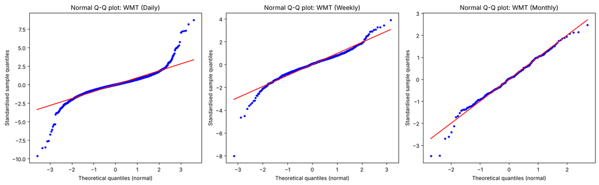

```python
fig, axes = plt.subplots(1, 3, figsize=(16, 5))
for i, (freq, tabela) in enumerate(frequencias.items()):
    r = tabela['WMT'].dropna()
    r_padronizado = (r - r.mean()) / r.std()      # média 0 e desvio-padrão 1
    stats.probplot(r_padronizado, dist='norm', plot=axes[i])
    axes[i].get_lines()[0].set_markersize(3)
    axes[i].get_lines()[1].set_color('red')
    axes[i].set_title(f'Normal Q-Q plot: WMT ({freq})')
    axes[i].set_xlabel('Theoretical quantiles (normal)')
    axes[i].set_ylabel('Standardised sample quantiles')
plt.tight_layout()
plt.savefig('../graficos/03_qqplot_normal_wmt_3freq.png', dpi=150)
plt.show()
```

```python
prob_normal_3sd = 2 * stats.norm.sf(3)   # P(|Z| > 3) numa normal = 0.27%

linhas = []
for ativo in ativos:
    for freq, tabela in frequencias.items():
        r = tabela[ativo].dropna()
        z = (r - r.mean()) / r.std()
        jb = stats.jarque_bera(r)
        teste_curtose = stats.kurtosistest(r)
        linhas.append({
            'Asset': ativo,
            'Frequency': freq,
            'Excess kurtosis': stats.kurtosis(r),
            'Kurtosis test p-value': teste_curtose.pvalue,
            'Jarque-Bera': jb.statistic,
            'JB p-value': jb.pvalue,
            '% |z|>3 (data)': 100 * (z.abs() > 3).mean(),
            '% |z|>3 (normal)': 100 * prob_normal_3sd,
        })

tab_normalidade = pd.DataFrame(linhas).set_index(['Asset', 'Frequency'])
display(tab_normalidade.round(4))
```

| Asset | Frequency | Excess kurtosis | Kurtosis test p-value | Jarque-Bera | JB p-value | % \|z\|>3 (data) | % \|z\|>3 (normal) |
| --- | --- | --- | --- | --- | --- | --- | --- |
| WMT | Daily | 14.3211 | 0.0000 | 35953.8399 | 0.0000 | 1.3803 | 0.27 |
|  | Weekly | 6.6738 | 0.0000 | 1722.0798 | 0.0000 | 1.7222 | 0.27 |
|  | Monthly | 0.8379 | 0.0358 | 10.1262 | 0.0063 | 1.0050 | 0.27 |
| SPY | Daily | 12.4025 | 0.0000 | 27147.1993 | 0.0000 | 1.4279 | 0.27 |
|  | Weekly | 5.8279 | 0.0000 | 1312.1190 | 0.0000 | 1.3777 | 0.27 |
|  | Monthly | 0.6703 | 0.0708 | 11.7175 | 0.0029 | 0.5025 | 0.27 |

**Leitura dos resultados (Facto 2):**

- **Diário:** excesso de curtose muito elevado (≈14) e Jarque-Bera com *p-value* ≈ 0 → normalidade claramente rejeitada. Há cerca de 5 vezes mais dias com movimentos acima de 3 desvios-padrão do que a normal prevê. O Q-Q plot "curva" nas duas caudas.
- **Semanal:** continua a haver caudas pesadas (excesso de curtose ≈ 7).
- **Mensal:** o excesso de curtose cai para valores perto de 1 → a distribuição aproxima-se da normal quando agregamos (efeito do Teorema do Limite Central), embora o Jarque-Bera ainda rejeite a 5%.

**Conclusão:** o facto é suportado e é **mais forte na frequência diária**, como o enunciado sugere.

## 5. Facto 3 — Assimetria (skewness negativa?)

- **Skewness < 0** → a cauda esquerda (perdas) é mais longa.
- **Teste de assimetria (`skewtest`):** H0 = skewness igual a 0. **Cuidado:** este teste assume que os dados têm caudas normais. Com caudas pesadas (Facto 2: excesso de curtose ≈ 14 no diário) ele rejeita H0 demasiadas vezes, mesmo quando a distribuição é simétrica. Por isso mostramos o *p-value* mas **não** decidimos com ele.
- **Bootstrap (o teste que usamos para decidir):** reamostramos os retornos com reposição 2000 vezes e calculamos a skewness de cada amostra. Isto dá um intervalo de confiança de 95% e a proporção de amostras com skewness ≥ 0 (= *p-value* unilateral para "skewness < 0"). Se o intervalo inclui o 0, a assimetria **não** é significativa. (Limitação: este bootstrap simples reamostra dias soltos e ignora o clustering de volatilidade.)
- Contamos também quantos retornos ficam abaixo de −3σ e acima de +3σ, e comparamos os quantis de 1% e 99%.

```python
np.random.seed(2026)      # semente -> o bootstrap dá sempre o mesmo resultado
N_BOOTSTRAP = 2000

linhas = []
for ativo in ativos:
    for freq, tabela in frequencias.items():
        r = tabela[ativo].dropna()
        z = (r - r.mean()) / r.std()
        teste_assimetria = stats.skewtest(r)

        # Bootstrap: reamostrar os retornos (com reposição) e recalcular a skewness muitas vezes
        skews_bootstrap = []
        for i in range(N_BOOTSTRAP):
            amostra = np.random.choice(r.values, size=len(r), replace=True)
            skews_bootstrap.append(stats.skew(amostra))
        skews_bootstrap = np.array(skews_bootstrap)

        linhas.append({
            'Asset': ativo,
            'Frequency': freq,
            'Skewness': stats.skew(r),
            'Skewtest p (assumes normal tails)': teste_assimetria.pvalue,
            'Bootstrap 95% CI low': np.percentile(skews_bootstrap, 2.5),
            'Bootstrap 95% CI high': np.percentile(skews_bootstrap, 97.5),
            'Bootstrap p (skew >= 0)': (skews_bootstrap >= 0).mean(),
            'N below -3σ': (z < -3).sum(),
            'N above +3σ': (z > 3).sum(),
            'Quantile 1%': r.quantile(0.01),
            'Quantile 99%': r.quantile(0.99),
        })

tab_assimetria = pd.DataFrame(linhas).set_index(['Asset', 'Frequency'])
display(tab_assimetria.round(4))
```

| Asset | Frequency | Skewness | Skewtest p (assumes normal tails) | Bootstrap 95% CI low | Bootstrap 95% CI high | Bootstrap p (skew >= 0) | N below -3σ | N above +3σ | Quantile 1% | Quantile 99% |
| --- | --- | --- | --- | --- | --- | --- | --- | --- | --- | --- |
| WMT | Daily | -0.2546 | 0.0000 | -1.1079 | 0.6029 | 0.2725 | 30 | 28 | -0.0325 | 0.0317 |
|  | Weekly | -0.8532 | 0.0000 | -1.7681 | 0.0028 | 0.0265 | 9 | 6 | -0.0795 | 0.0767 |
|  | Monthly | -0.3603 | 0.0367 | -0.7556 | 0.1454 | 0.0830 | 2 | 0 | -0.1297 | 0.1208 |
| SPY | Daily | -0.5549 | 0.0000 | -1.4042 | 0.2772 | 0.1130 | 39 | 21 | -0.0308 | 0.0261 |
|  | Weekly | -0.7400 | 0.0000 | -1.5105 | 0.0145 | 0.0285 | 8 | 4 | -0.0605 | 0.0569 |
|  | Monthly | -0.4909 | 0.0053 | -0.8507 | -0.1117 | 0.0050 | 1 | 0 | -0.0923 | 0.1033 |

**Leitura dos resultados (Facto 3):**

- A skewness da WMT é **negativa nas três frequências**, mas só é estatisticamente significativa na **semanal** (bootstrap: *p* ≈ 0.03 e o intervalo de 95% fica praticamente todo abaixo de 0).
- **Diária:** skewness ≈ −0.25, mas o intervalo do bootstrap é muito largo (≈ −1.1 a +0.6) e inclui o 0 → **não significativa**. O valor depende de poucos dias extremos (grandes quedas em dias de resultados trimestrais). Os quantis de 1% e 99% são quase simétricos e o nº de dias abaixo de −3σ (30) é quase igual ao nº acima de +3σ (28): o "corpo" da distribuição é simétrico. O `skewtest` dá *p* ≈ 0, mas isso é um falso alarme causado pelas caudas pesadas.
- **Mensal:** skewness ≈ −0.36, *p* do bootstrap ≈ 0.08 → evidência fraca, não significativa a 5%.
- **SPY:** skewness negativa nas três frequências, significativa na semanal e na mensal. Nas frequências diária e mensal é mais negativa do que a da WMT; na semanal a da WMT é mais negativa.

**Conclusão:** a skewness é sempre negativa, mas só há evidência estatística robusta na frequência semanal. Para a WMT (ação defensiva) a assimetria negativa é **fraca** — o facto é apenas parcialmente suportado.

## 6. Facto 4 — Clustering de volatilidade

Se a volatilidade se agrupa no tempo, os **retornos absolutos |r|** e **ao quadrado r²** estão autocorrelacionados (dias agitados seguem-se a dias agitados), mesmo que os retornos *r* não estejam.

- Gráfico dos retornos + volatilidade móvel de 21 dias (≈ 1 mês);
- ACF de |r| e r² nas 3 frequências;
- Ljung-Box em |r| e r² e teste **ARCH-LM** de Engle (H0 = não há efeitos ARCH, isto é, variância constante).

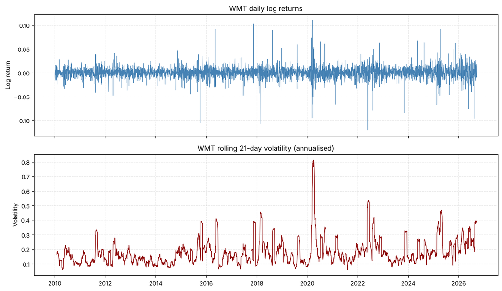

```python
r_d = ret_d['WMT'].dropna()
vol_movel = r_d.rolling(21).std() * np.sqrt(252)    # volatilidade de 21 dias, anualizada

fig, axes = plt.subplots(2, 1, figsize=(12, 7), sharex=True)
axes[0].plot(r_d.index, r_d, linewidth=0.6, color='steelblue')
axes[0].set_title('WMT daily log returns')
axes[0].set_ylabel('Log return')
axes[0].grid(True, linestyle='--', alpha=0.3)

axes[1].plot(vol_movel.index, vol_movel, linewidth=1, color='darkred')
axes[1].set_title('WMT rolling 21-day volatility (annualised)')
axes[1].set_ylabel('Volatility')
axes[1].grid(True, linestyle='--', alpha=0.3)

plt.tight_layout()
plt.savefig('../graficos/03_volatilidade_movel_wmt.png', dpi=150)
plt.show()
```

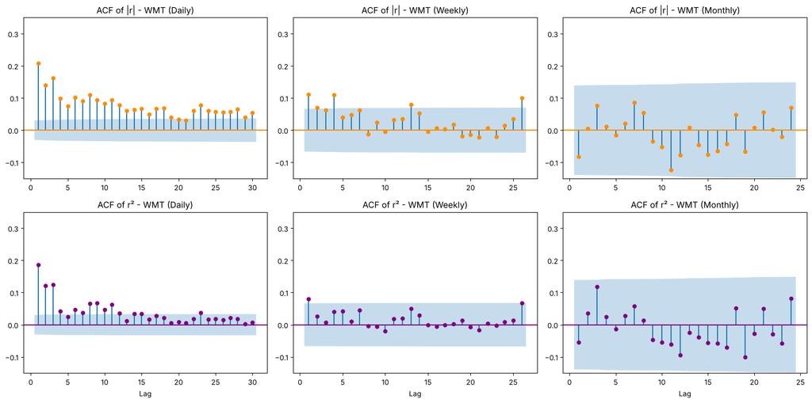

```python
fig, axes = plt.subplots(2, 3, figsize=(16, 8))
for j, (freq, tabela) in enumerate(frequencias.items()):
    r = tabela['WMT'].dropna()

    # Linha de cima: retornos absolutos
    plot_acf(r.abs(), lags=lags_grafico[freq], ax=axes[0, j], zero=False, color='darkorange')
    axes[0, j].set_title(f'ACF of |r| - WMT ({freq})')
    axes[0, j].set_ylim(-0.15, 0.35)

    # Linha de baixo: retornos ao quadrado
    plot_acf(r ** 2, lags=lags_grafico[freq], ax=axes[1, j], zero=False, color='purple')
    axes[1, j].set_title(f'ACF of r² - WMT ({freq})')
    axes[1, j].set_ylim(-0.15, 0.35)
    axes[1, j].set_xlabel('Lag')

plt.tight_layout()
plt.savefig('../graficos/03_acf_abs_quadrado_wmt.png', dpi=150)
plt.show()
```

```python
linhas = []
for ativo in ativos:
    for freq, tabela in frequencias.items():
        r = tabela[ativo].dropna()
        lag = lags_teste[freq][1]      # lag do meio: 10 (diário), 8 (semanal), 6 (mensal)

        lb_abs = acorr_ljungbox(r.abs(), lags=[lag])
        lb_quad = acorr_ljungbox(r ** 2, lags=[lag])
        teste_arch = het_arch(r - r.mean(), nlags=lag)   # devolve (estatística LM, p-value, F, p-value do F)

        linhas.append({
            'Asset': ativo,
            'Frequency': freq,
            'Lag': lag,
            'LB |r| p-value': lb_abs['lb_pvalue'].iloc[0],
            'LB r² p-value': lb_quad['lb_pvalue'].iloc[0],
            'ARCH-LM stat': teste_arch[0],
            'ARCH-LM p-value': teste_arch[1],
        })

tab_clustering = pd.DataFrame(linhas).set_index(['Asset', 'Frequency'])
display(tab_clustering.round(4))
```

| Asset | Frequency | Lag | LB \|r\| p-value | LB r² p-value | ARCH-LM stat | ARCH-LM p-value |
| --- | --- | --- | --- | --- | --- | --- |
| WMT | Daily | 10 | 0.0000 | 0.0000 | 235.8985 | 0.0000 |
|  | Weekly | 8 | 0.0000 | 0.1880 | 8.9008 | 0.3507 |
|  | Monthly | 6 | 0.8478 | 0.6722 | 3.3293 | 0.7665 |
| SPY | Daily | 10 | 0.0000 | 0.0000 | 1214.4835 | 0.0000 |
|  | Weekly | 8 | 0.0000 | 0.0000 | 248.4325 | 0.0000 |
|  | Monthly | 6 | 0.0053 | 0.0006 | 28.1544 | 0.0001 |

**Leitura dos resultados (Facto 4):**

- **Diário:** as ACF de |r| e r² são positivas e significativas durante muitos lags e decaem devagar; Ljung-Box e ARCH-LM rejeitam H0 com *p-values* ≈ 0 → **clustering de volatilidade forte**. No gráfico vê-se bem: períodos calmos alternam com períodos agitados (ex.: março de 2020).
- **Semanal:** evidência mais fraca — significativa em |r| mas não em r² nem no ARCH-LM.
- **Mensal:** sem evidência para a WMT (os *p-values* ficam acima de 0.05). Já o SPY mantém clustering mesmo na frequência mensal.

**Conclusão:** facto suportado na frequência diária; enfraquece à medida que agregamos os retornos (para a WMT desaparece no mensal).

## 7. Facto 5 — Efeito alavanca (resposta assimétrica da volatilidade)

**7.1 Teste simples:** correlação entre o retorno de hoje $r_t$ e a magnitude do retorno de daqui a *k* dias $|r_{t+k}|$. Se for **negativa**, então quedas hoje estão associadas a mais volatilidade no futuro → efeito alavanca.

**7.2 Modelo GJR-GARCH(1,1):**

$$\sigma_t^2 = \omega + \left(\alpha + \gamma \cdot I_{\{\varepsilon_{t-1}<0\}}\right)\varepsilon_{t-1}^2 + \beta\,\sigma_{t-1}^2$$

- $I_{\{\varepsilon_{t-1}<0\}}$ vale 1 se o choque de ontem foi negativo e 0 caso contrário;
- **γ > 0 e significativo** → choques negativos aumentam mais a volatilidade do que choques positivos do mesmo tamanho.

Estimamos o modelo com inovações **normais** e **Student-t** (esta última permite caudas pesadas).

| k (days ahead) | WMT | SPY |
| --- | --- | --- |
| 1 | -0.0731 | -0.1174 |
| 2 | 0.0008 | -0.1511 |
| 3 | -0.0251 | -0.1072 |
| 4 | -0.0427 | -0.1651 |
| 5 | 0.0068 | -0.0712 |
| 6 | -0.0133 | -0.1240 |
| 7 | -0.0156 | -0.0500 |
| 8 | -0.0140 | -0.0739 |
| 9 | -0.0015 | -0.0522 |
| 10 | -0.0139 | -0.0674 |

```
Banda de 95% aproximada: ±0.0302
```

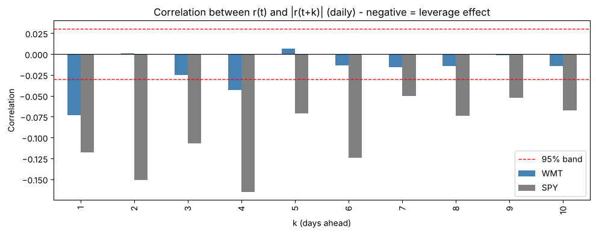

```python
linhas = []
for k in range(1, 11):
    linha = {'k (days ahead)': k}
    for ativo in ativos:
        r = ret_d[ativo].dropna()
        linha[ativo] = r.corr(r.shift(-k).abs())     # corr( r_t , |r_{t+k}| )
    linhas.append(linha)

tab_alavanca_simples = pd.DataFrame(linhas).set_index('k (days ahead)')
banda = 1.96 / np.sqrt(len(ret_d['WMT'].dropna()))
display(tab_alavanca_simples.round(4))
print(f'Banda de 95% aproximada: ±{banda:.4f}')

# Gráfico de barras lado a lado
ax = tab_alavanca_simples.plot(kind='bar', figsize=(10, 4), color=['steelblue', 'grey'])
ax.axhline(banda, color='red', linestyle='--', linewidth=1)
ax.axhline(-banda, color='red', linestyle='--', linewidth=1, label='95% band')
ax.axhline(0, color='black', linewidth=0.8)
ax.set_title('Correlation between r(t) and |r(t+k)| (daily) - negative = leverage effect')
ax.set_xlabel('k (days ahead)')
ax.set_ylabel('Correlation')
ax.legend()
plt.tight_layout()
plt.savefig('../graficos/03_correlacao_alavanca.png', dpi=150)
plt.show()
```

```python
def ajustar_gjr(r, distribuicao):
    # GJR-GARCH(1,1) com média constante.
    # Multiplicamos os retornos por 100 (ficam em %) porque o otimizador da biblioteca 'arch'
    # funciona melhor com números nessa escala.
    modelo = arch_model(100 * r.dropna(), mean='Constant', vol='GARCH', p=1, o=1, q=1, dist=distribuicao)
    return modelo.fit(disp='off')


# Guardamos todos os modelos num dicionário com chave (ativo, frequência, distribuição)
modelos = {}
for ativo in ativos:
    for freq, tabela in frequencias.items():
        for distribuicao in ['normal', 't']:
            modelos[(ativo, freq, distribuicao)] = ajustar_gjr(tabela[ativo], distribuicao)

# Tabela com os parâmetros mais importantes
linhas = []
for (ativo, freq, distribuicao), res in modelos.items():
    p = res.params
    linhas.append({
        'Asset': ativo,
        'Frequency': freq,
        'Innovations': distribuicao,
        'omega': p['omega'],
        'alpha': p['alpha[1]'],
        'gamma': p['gamma[1]'],
        'gamma p-value': res.pvalues['gamma[1]'],
        'beta': p['beta[1]'],
        'persistence (α+γ/2+β)': p['alpha[1]'] + p['gamma[1]'] / 2 + p['beta[1]'],
        'nu (t d.o.f.)': p['nu'] if distribuicao == 't' else np.nan,
        'Log-lik.': res.loglikelihood,
        'AIC': res.aic,
        'BIC': res.bic,
    })

tab_gjr = pd.DataFrame(linhas).set_index(['Asset', 'Frequency', 'Innovations'])
display(tab_gjr.round(4))
```

| Asset | Frequency | Innovations | omega | alpha | gamma | gamma p-value | beta | persistence (α+γ/2+β) | nu (t d.o.f.) | Log-lik. | AIC | BIC |
| --- | --- | --- | --- | --- | --- | --- | --- | --- | --- | --- | --- | --- |
| WMT | Daily | normal | 0.1425 | 0.0394 | 0.0811 | 0.2022 | 0.8309 | 0.9108 | NaN | -6685.1872 | 13380.3744 | 13412.0910 |
|  |  | t | 0.1190 | 0.0612 | 0.0706 | 0.0055 | 0.8222 | 0.9188 | 3.9306 | -6155.8146 | 12323.6293 | 12361.6892 |
|  | Weekly | normal | 0.0226 | 0.0000 | 0.0000 | 1.0000 | 0.9982 | 0.9982 | NaN | -2085.2777 | 4180.5554 | 4204.4036 |
|  |  | t | 0.3158 | 0.0451 | 0.0010 | 0.9788 | 0.9151 | 0.9608 | 4.1228 | -2025.0373 | 4062.0747 | 4090.6925 |
|  | Monthly | normal | 3.0543 | 0.0807 | -0.0807 | 0.2762 | 0.8493 | 0.8897 | NaN | -607.2270 | 1224.4540 | 1240.9205 |
|  |  | t | 0.0872 | 0.0000 | 0.0000 | 1.0000 | 1.0000 | 1.0000 | 12.3477 | -605.2993 | 1222.5985 | 1242.3583 |
| SPY | Daily | normal | 0.0380 | 0.0156 | 0.2343 | 0.0000 | 0.8279 | 0.9606 | NaN | -5309.6837 | 10629.3673 | 10661.0839 |
|  |  | t | 0.0294 | 0.0000 | 0.2805 | 0.0000 | 0.8332 | 0.9734 | 5.8235 | -5176.5349 | 10365.0698 | 10403.1297 |
|  | Weekly | normal | 0.4712 | 0.0094 | 0.4944 | 0.0000 | 0.6615 | 0.9181 | NaN | -1796.1515 | 3602.3030 | 3626.1512 |
|  |  | t | 0.4259 | 0.0000 | 0.4542 | 0.0000 | 0.6823 | 0.9094 | 8.1342 | -1778.7642 | 3569.5285 | 3598.1463 |
|  | Monthly | normal | 4.5371 | 0.0000 | 0.5184 | 0.0131 | 0.4593 | 0.7185 | NaN | -545.8784 | 1101.7568 | 1118.2233 |
|  |  | t | 4.4936 | 0.0000 | 0.5710 | 0.5813 | 0.4392 | 0.7247 | 14.3153 | -545.4933 | 1102.9866 | 1122.7464 |

Mostramos o resumo completo do modelo diário da WMT com inovações Student-t (o modelo escolhido, por ter o AIC mais baixo):

```python
print(modelos[('WMT', 'Daily', 't')].summary())
```

```
                      Constant Mean - GJR-GARCH Model Results
====================================================================================
Dep. Variable:                          WMT   R-squared:                       0.000
Mean Model:                   Constant Mean   Adj. R-squared:                  0.000
Vol Model:                        GJR-GARCH   Log-Likelihood:               -6155.81
Distribution:      Standardized Student's t   AIC:                           12323.6
Method:                  Maximum Likelihood   BIC:                           12361.7
                                              No. Observations:                 4202
Date:                      Wed, Oct 07 2026   Df Residuals:                     4201
Time:                              16:40:45   Df Model:                            1
                                 Mean Model
============================================================================
                 coef    std err          t      P>|t|      95.0% Conf. Int.
----------------------------------------------------------------------------
mu             0.0667  1.412e-02      4.725  2.302e-06 [3.904e-02,9.439e-02]
                              Volatility Model
===========================================================================
                 coef    std err          t      P>|t|     95.0% Conf. Int.
---------------------------------------------------------------------------
omega          0.1190  7.766e-02      1.532      0.126 [-3.325e-02,  0.271]
alpha[1]       0.0612  4.561e-02      1.343      0.179 [-2.815e-02,  0.151]
gamma[1]       0.0706  2.544e-02      2.775  5.518e-03  [2.074e-02,  0.120]
beta[1]        0.8222  9.590e-02      8.574  1.003e-17    [  0.634,  1.010]
                              Distribution
========================================================================
                 coef    std err          t      P>|t|  95.0% Conf. Int.
------------------------------------------------------------------------
nu             3.9306      0.266     14.801  1.434e-49 [  3.410,  4.451]
========================================================================

Covariance estimator: robust
```

**Curva de impacto de notícias (News Impact Curve):** mostra quanto aumenta a variância de amanhã para um choque de hoje de tamanho ε. Se a curva for mais inclinada do lado esquerdo (choques negativos), existe efeito alavanca.

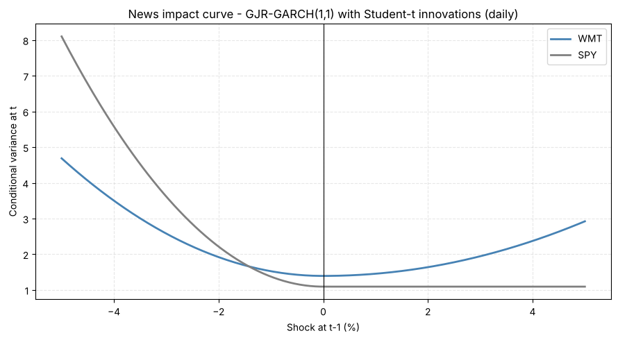

```python
choques = np.linspace(-5, 5, 201)          # choques de -5% a +5%

plt.figure(figsize=(9, 5))
for ativo, cor in zip(ativos, ['steelblue', 'grey']):
    res = modelos[(ativo, 'Daily', 't')]
    p = res.params
    variancia_media = (res.conditional_volatility ** 2).mean()   # nível "normal" de variância

    # Indicador: 1 se o choque é negativo, 0 se é positivo
    negativo = (choques < 0).astype(int)
    nova_variancia = p['omega'] + (p['alpha[1]'] + p['gamma[1]'] * negativo) * choques ** 2 + p['beta[1]'] * variancia_media
    plt.plot(choques, nova_variancia, label=ativo, color=cor, linewidth=2)

plt.axvline(0, color='black', linewidth=0.8)
plt.title('News impact curve - GJR-GARCH(1,1) with Student-t innovations (daily)')
plt.xlabel('Shock at t-1 (%)')
plt.ylabel('Conditional variance at t')
plt.legend()
plt.grid(True, linestyle='--', alpha=0.3)
plt.tight_layout()
plt.savefig('../graficos/03_news_impact_curve.png', dpi=150)
plt.show()
```

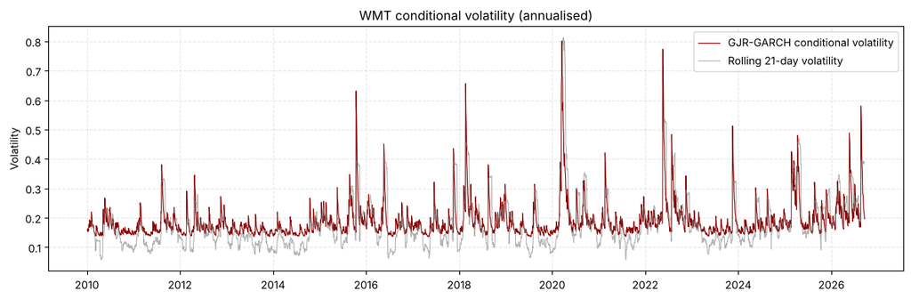

```python
# Volatilidade condicional estimada pelo GJR-GARCH (anualizada, em decimal)
res_wmt = modelos[('WMT', 'Daily', 't')]
vol_condicional = res_wmt.conditional_volatility / 100 * np.sqrt(252)

plt.figure(figsize=(12, 4))
plt.plot(vol_condicional.index, vol_condicional, color='darkred', linewidth=0.8, label='GJR-GARCH conditional volatility')
plt.plot(vol_movel.index, vol_movel, color='grey', linewidth=0.8, alpha=0.6, label='Rolling 21-day volatility')
plt.title('WMT conditional volatility (annualised)')
plt.ylabel('Volatility')
plt.legend()
plt.grid(True, linestyle='--', alpha=0.3)
plt.tight_layout()
plt.savefig('../graficos/03_volatilidade_condicional_wmt.png', dpi=150)
plt.show()
```

**Leitura dos resultados (Facto 5):**

- **Correlação simples:** para a WMT, $corr(r_t, |r_{t+1}|)$ é negativa e significativa no lag 1, mas fraca nos lags seguintes. Para o SPY é negativa e fora da banda de 95% em todos os 10 lags → efeito alavanca muito mais forte no mercado.
- **GJR-GARCH diário da WMT (Student-t):** γ ≈ 0.07 e significativo (*p* < 0.01) → choques negativos aumentam mais a volatilidade. Com inovações normais o γ não é significativo, pelo que a evidência para a WMT é **moderada** e depende da especificação.
- **SPY:** γ ≈ 0.2–0.3 e muito significativo, com α ≈ 0 → praticamente só os choques negativos fazem subir a volatilidade.
- **Semanal / mensal (WMT):** γ não é significativo. Atenção a dois modelos "degenerados" (sem dinâmica de volatilidade): o semanal com inovações normais (α = γ = 0 e β ≈ 1) e o mensal com Student-t (α = γ = 0 e β = 1). Nesses casos a volatilidade estimada só sobe em linha reta ao longo do tempo. Com apenas ~200 observações mensais o GARCH mensal é pouco fiável, por isso não tiramos conclusões fortes dessa frequência (e na semanal usamos o modelo t).

**Conclusão:** existe efeito alavanca na WMT diária, mas é fraco quando comparado com o índice; não é visível nas frequências mais baixas.

## 8. Facto 6 — Não-normalidade condicional (resíduos padronizados)

Os **resíduos padronizados** são $z_t = \varepsilon_t / \sigma_t$, ou seja, o choque de cada dia dividido pela volatilidade prevista pelo GARCH. Se o modelo GARCH com inovações normais fosse correto, $z_t$ seria normal (0, 1).

Testamos:

- normalidade dos $z_t$ (skewness, curtose, Jarque-Bera);
- autocorrelação de $z_t$ e $z_t^2$ (Ljung-Box) → para ver se o GARCH "limpou" o clustering;
- Q-Q plots contra a **normal** e contra a **Student-t** (com os graus de liberdade estimados).

```python
linhas = []
for ativo in ativos:
    for freq in frequencias.keys():
        for distribuicao in ['normal', 't']:
            res = modelos[(ativo, freq, distribuicao)]
            z = res.std_resid.dropna()
            lag = lags_teste[freq][1]
            linhas.append({
                'Asset': ativo,
                'Frequency': freq,
                'Innovations': distribuicao,
                'z skewness': stats.skew(z),
                'z excess kurtosis': stats.kurtosis(z),
                'z JB p-value': stats.jarque_bera(z).pvalue,
                'LB z p-value': acorr_ljungbox(z, lags=[lag])['lb_pvalue'].iloc[0],
                'LB z² p-value': acorr_ljungbox(z ** 2, lags=[lag])['lb_pvalue'].iloc[0],
            })

tab_residuos = pd.DataFrame(linhas).set_index(['Asset', 'Frequency', 'Innovations'])
display(tab_residuos.round(4))
```

| Asset | Frequency | Innovations | z skewness | z excess kurtosis | z JB p-value | LB z p-value | LB z² p-value |
| --- | --- | --- | --- | --- | --- | --- | --- |
| WMT | Daily | normal | -0.6435 | 15.0211 | 0.0000 | 0.1280 | 0.9884 |
|  |  | t | -0.6617 | 15.6666 | 0.0000 | 0.1406 | 0.9623 |
|  | Weekly | normal | -0.7837 | 4.6165 | 0.0000 | 0.1882 | 0.6586 |
|  |  | t | -0.9945 | 7.1261 | 0.0000 | 0.2968 | 0.9997 |
|  | Monthly | normal | -0.2505 | 0.5307 | 0.1098 | 0.7510 | 0.8284 |
|  |  | t | -0.3228 | 0.6633 | 0.0287 | 0.7561 | 0.8850 |
| SPY | Daily | normal | -0.7294 | 2.6005 | 0.0000 | 0.5090 | 0.5369 |
|  |  | t | -0.7944 | 3.1670 | 0.0000 | 0.3530 | 0.6615 |
|  | Weekly | normal | -0.8441 | 2.3225 | 0.0000 | 0.4483 | 0.8499 |
|  |  | t | -0.8504 | 2.3427 | 0.0000 | 0.3841 | 0.8887 |
|  | Monthly | normal | -0.7533 | 0.2611 | 0.0001 | 0.6332 | 0.8340 |
|  |  | t | -0.7752 | 0.3325 | 0.0000 | 0.5989 | 0.7945 |

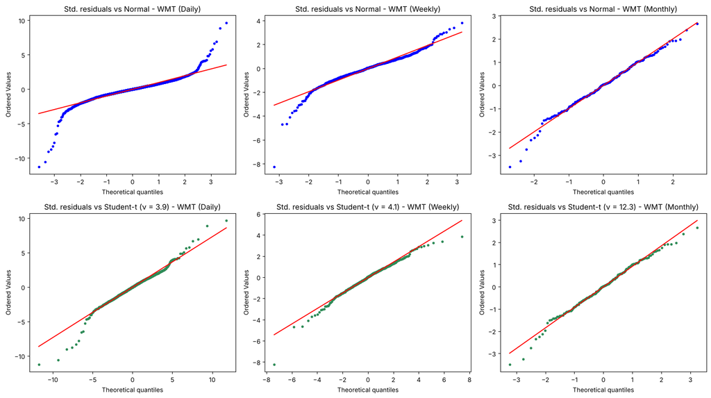

```python
# Q-Q plots dos resíduos padronizados da WMT (modelo Student-t), nas 3 frequências
fig, axes = plt.subplots(2, 3, figsize=(16, 9))
for j, freq in enumerate(frequencias.keys()):
    res = modelos[('WMT', freq, 't')]
    z = res.std_resid.dropna()
    nu = res.params['nu']

    # Linha de cima: contra a normal
    stats.probplot(z, dist='norm', plot=axes[0, j])
    axes[0, j].get_lines()[0].set_markersize(3)
    axes[0, j].get_lines()[1].set_color('red')
    axes[0, j].set_title(f'Std. residuals vs Normal - WMT ({freq})')

    # Linha de baixo: contra a Student-t com os graus de liberdade estimados
    stats.probplot(z, dist=stats.t, sparams=(nu,), plot=axes[1, j])
    axes[1, j].get_lines()[0].set_markersize(3)
    axes[1, j].get_lines()[0].set_color('seagreen')
    axes[1, j].get_lines()[1].set_color('red')
    axes[1, j].set_title(f'Std. residuals vs Student-t (ν = {nu:.1f}) - WMT ({freq})')

plt.tight_layout()
plt.savefig('../graficos/03_qqplot_residuos_padronizados_wmt.png', dpi=150)
plt.show()
```

```python
# Os maiores resíduos padronizados (em valor absoluto) - em que dias aconteceram?
res = modelos[('WMT', 'Daily', 't')]
z = res.std_resid.dropna()

maiores = z.abs().sort_values(ascending=False).head(8).index
tab_maiores = pd.DataFrame({
    'Log return': ret_d.loc[maiores, 'WMT'],
    'Std. residual z': z.loc[maiores],
})
tab_maiores.index = tab_maiores.index.date
display(tab_maiores.round(4))
```

|  | Log return | Std. residual z |
| --- | --- | --- |
| 2015-10-14 | -0.1058 | -11.2400 |
| 2022-05-17 | -0.1208 | -10.5660 |
| 2017-11-16 | 0.1034 | 9.6584 |
| 2026-08-20 | -0.0960 | -9.0333 |
| 2018-08-16 | 0.0892 | 8.8612 |
| 2023-11-16 | -0.0844 | -8.7594 |
| 2022-07-26 | -0.0791 | -8.3086 |
| 2018-02-20 | -0.1074 | -7.7712 |

**Leitura dos resultados (Facto 6):**

- Depois de modelar a volatilidade, os resíduos padronizados diários da WMT **continuam a não ser normais**: excesso de curtose muito alto e Jarque-Bera com *p-value* ≈ 0 → **não-normalidade condicional**.
- O Q-Q plot contra a normal afasta-se muito nas caudas; contra a Student-t (ν ≈ 4) o ajuste é bastante melhor, embora os dias mais extremos ainda fiquem fora da linha.
- O modelo com inovações Student-t tem AIC muito mais baixo do que o normal (tabela da secção 7) → as caudas pesadas são relevantes.
- O Ljung-Box de $z_t^2$ já **não** é significativo → o GJR-GARCH captou bem o clustering de volatilidade. O Ljung-Box de $z_t$ também não é significativo → a pequena autocorrelação "significativa" do Facto 1 desaparece quando se controla a volatilidade.
- Os maiores resíduos coincidem com datas do calendário de resultados trimestrais da Walmart (meados de fevereiro, maio, agosto e novembro) ou com revisões de *guidance*: são **saltos** de informação que nenhum modelo GARCH consegue antecipar. Este é o principal motivo das caudas pesadas.
- Na frequência mensal os resíduos já estão perto da normal (excesso de curtose < 1): o Jarque-Bera só rejeita no modelo t (p ≈ 0.03) e não no modelo normal (p ≈ 0.11). Como o GARCH mensal é pouco fiável (ver Facto 5), a evidência mensal é **fraca**.

**Conclusão:** existe não-normalidade condicional clara na frequência diária e semanal; a Student-t é uma escolha mais adequada do que a normal. Na frequência mensal a evidência é fraca.

## 9. Tabela-resumo dos factos estilizados

Construímos a conclusão de cada facto com regras simples (todas a 5%):

| Facto | Regra usada |
| --- | --- |
| 1. Pouca autocorrelação | Ljung-Box (lag do meio) não rejeita → *Supported*; rejeita mas max\|ρ(1..5)\| < 0.10 → *Supported (significant but tiny)*; caso contrário → *Not supported* |
| 2. Caudas pesadas / não normal | JB rejeita e excesso de curtose > 0 → *Supported* |
| 3. Skewness negativa | skewness < 0 e *p* do bootstrap (skew ≥ 0) < 0.05 → *Supported*; caso contrário → *Not significant* (o `skewtest` não é usado porque assume caudas normais) |
| 4. Clustering de volatilidade | Ljung-Box em \|r\| **e** r² rejeitam → *Supported*; só um → *Partial*; nenhum → *Not supported* |
| 5. Efeito alavanca | γ > 0 e significativo no GJR-GARCH-t → *Supported* |
| 6. Não-normalidade condicional | JB dos resíduos padronizados (GJR-GARCH-t) rejeita → *Supported* |

```python
linhas = []
for ativo in ativos:
    for freq, tabela in frequencias.items():
        r = tabela[ativo].dropna()
        lag = lags_teste[freq][1]

        # ---- Facto 1: autocorrelação
        p_lb = acorr_ljungbox(r, lags=[lag])['lb_pvalue'].iloc[0]
        maior_acf = np.abs(acf(r, nlags=5)[1:]).max()
        if p_lb >= ALFA:
            conclusao = 'Supported'
        elif maior_acf < 0.10:
            conclusao = 'Supported (significant but tiny)'
        else:
            conclusao = 'Not supported'
        linhas.append({'Asset': ativo, 'Frequency': freq, 'Fact': '1. Little serial correlation',
                       'Statistic': f'max |ACF(1-5)| = {maior_acf:.3f}', 'p-value': p_lb, 'Conclusion': conclusao})

        # ---- Facto 2: não normal / caudas pesadas
        p_jb = stats.jarque_bera(r).pvalue
        curtose = stats.kurtosis(r)
        conclusao = 'Supported' if (p_jb < ALFA and curtose > 0) else 'Not supported'
        linhas.append({'Asset': ativo, 'Frequency': freq, 'Fact': '2. Non-normal, fat tails',
                       'Statistic': f'excess kurtosis = {curtose:.2f}', 'p-value': p_jb, 'Conclusion': conclusao})

        # ---- Facto 3: skewness negativa
        assimetria = stats.skew(r)
        p_skew = tab_assimetria.loc[(ativo, freq), 'Bootstrap p (skew >= 0)']    # bootstrap da secção 5
        conclusao = 'Supported' if (assimetria < 0 and p_skew < ALFA) else 'Not significant'
        linhas.append({'Asset': ativo, 'Frequency': freq, 'Fact': '3. Negative skewness',
                       'Statistic': f'skewness = {assimetria:.3f}', 'p-value': p_skew, 'Conclusion': conclusao})

        # ---- Facto 4: clustering de volatilidade
        p_abs = acorr_ljungbox(r.abs(), lags=[lag])['lb_pvalue'].iloc[0]
        p_quad = acorr_ljungbox(r ** 2, lags=[lag])['lb_pvalue'].iloc[0]
        n_rejeicoes = int(p_abs < ALFA) + int(p_quad < ALFA)
        if n_rejeicoes == 2:
            conclusao = 'Supported'
        elif n_rejeicoes == 1:
            conclusao = 'Partial'
        else:
            conclusao = 'Not supported'
        linhas.append({'Asset': ativo, 'Frequency': freq, 'Fact': '4. Volatility clustering',
                       'Statistic': f'LB |r| p = {p_abs:.3f}', 'p-value': p_quad, 'Conclusion': conclusao})

        # ---- Facto 5: efeito alavanca (GJR-GARCH com Student-t)
        res = modelos[(ativo, freq, 't')]
        gama = res.params['gamma[1]']
        p_gama = res.pvalues['gamma[1]']
        conclusao = 'Supported' if (gama > 0 and p_gama < ALFA) else 'Not significant'
        linhas.append({'Asset': ativo, 'Frequency': freq, 'Fact': '5. Leverage effect',
                       'Statistic': f'gamma = {gama:.3f}', 'p-value': p_gama, 'Conclusion': conclusao})

        # ---- Facto 6: não-normalidade condicional
        z = res.std_resid.dropna()
        p_jb_z = stats.jarque_bera(z).pvalue
        conclusao = 'Supported' if p_jb_z < ALFA else 'Not supported'
        linhas.append({'Asset': ativo, 'Frequency': freq, 'Fact': '6. Conditional non-normality',
                       'Statistic': f'z excess kurtosis = {stats.kurtosis(z):.2f}', 'p-value': p_jb_z, 'Conclusion': conclusao})

tab_resumo = pd.DataFrame(linhas)
# Nota: no facto 4, a coluna 'p-value' refere-se ao Ljung-Box de r² (o de |r| está na coluna 'Statistic')

# Versão "larga" só com as conclusões: factos nas linhas, frequências nas colunas
resumo_wmt = tab_resumo[tab_resumo['Asset'] == 'WMT'].pivot(index='Fact', columns='Frequency', values='Conclusion')
resumo_wmt = resumo_wmt[['Daily', 'Weekly', 'Monthly']]
print('WMT - conclusão por facto e frequência')
display(resumo_wmt)

resumo_spy = tab_resumo[tab_resumo['Asset'] == 'SPY'].pivot(index='Fact', columns='Frequency', values='Conclusion')
resumo_spy = resumo_spy[['Daily', 'Weekly', 'Monthly']]
print('SPY - conclusão por facto e frequência (comparação)')
display(resumo_spy)
```

```
WMT - conclusão por facto e frequência
```

| Frequency Fact | Daily | Weekly | Monthly |
| --- | --- | --- | --- |
| 1. Little serial correlation | Supported (significant but tiny) | Supported | Supported |
| 2. Non-normal, fat tails | Supported | Supported | Supported |
| 3. Negative skewness | Not significant | Supported | Not significant |
| 4. Volatility clustering | Supported | Partial | Not supported |
| 5. Leverage effect | Supported | Not significant | Not significant |
| 6. Conditional non-normality | Supported | Supported | Supported |

```
SPY - conclusão por facto e frequência (comparação)
```

| Frequency Fact | Daily | Weekly | Monthly |
| --- | --- | --- | --- |
| 1. Little serial correlation | Not supported | Supported (significant but tiny) | Supported |
| 2. Non-normal, fat tails | Supported | Supported | Supported |
| 3. Negative skewness | Not significant | Supported | Supported |
| 4. Volatility clustering | Supported | Supported | Supported |
| 5. Leverage effect | Supported | Supported | Not significant |
| 6. Conditional non-normality | Supported | Supported | Supported |

```python
display(tab_resumo.round(4))
```

|  | Asset | Frequency | Fact | Statistic | p-value | Conclusion |
| --- | --- | --- | --- | --- | --- | --- |
| 0 | WMT | Daily | 1. Little serial correlation | max \|ACF(1-5)\| = 0.041 | 0.0011 | Supported (significant but tiny) |
| 1 | WMT | Daily | 2. Non-normal, fat tails | excess kurtosis = 14.32 | 0.0000 | Supported |
| 2 | WMT | Daily | 3. Negative skewness | skewness = -0.255 | 0.2725 | Not significant |
| 3 | WMT | Daily | 4. Volatility clustering | LB \|r\| p = 0.000 | 0.0000 | Supported |
| 4 | WMT | Daily | 5. Leverage effect | gamma = 0.071 | 0.0055 | Supported |
| 5 | WMT | Daily | 6. Conditional non-normality | z excess kurtosis = 15.67 | 0.0000 | Supported |
| 6 | WMT | Weekly | 1. Little serial correlation | max \|ACF(1-5)\| = 0.095 | 0.1406 | Supported |
| 7 | WMT | Weekly | 2. Non-normal, fat tails | excess kurtosis = 6.67 | 0.0000 | Supported |
| 8 | WMT | Weekly | 3. Negative skewness | skewness = -0.853 | 0.0265 | Supported |
| 9 | WMT | Weekly | 4. Volatility clustering | LB \|r\| p = 0.000 | 0.1880 | Partial |
| 10 | WMT | Weekly | 5. Leverage effect | gamma = 0.001 | 0.9788 | Not significant |
| 11 | WMT | Weekly | 6. Conditional non-normality | z excess kurtosis = 7.13 | 0.0000 | Supported |
| 12 | WMT | Monthly | 1. Little serial correlation | max \|ACF(1-5)\| = 0.070 | 0.6583 | Supported |
| 13 | WMT | Monthly | 2. Non-normal, fat tails | excess kurtosis = 0.84 | 0.0063 | Supported |
| 14 | WMT | Monthly | 3. Negative skewness | skewness = -0.360 | 0.0830 | Not significant |
| 15 | WMT | Monthly | 4. Volatility clustering | LB \|r\| p = 0.848 | 0.6722 | Not supported |
| 16 | WMT | Monthly | 5. Leverage effect | gamma = 0.000 | 1.0000 | Not significant |
| 17 | WMT | Monthly | 6. Conditional non-normality | z excess kurtosis = 0.66 | 0.0287 | Supported |
| 18 | SPY | Daily | 1. Little serial correlation | max \|ACF(1-5)\| = 0.100 | 0.0000 | Not supported |
| 19 | SPY | Daily | 2. Non-normal, fat tails | excess kurtosis = 12.40 | 0.0000 | Supported |
| 20 | SPY | Daily | 3. Negative skewness | skewness = -0.555 | 0.1130 | Not significant |
| 21 | SPY | Daily | 4. Volatility clustering | LB \|r\| p = 0.000 | 0.0000 | Supported |
| 22 | SPY | Daily | 5. Leverage effect | gamma = 0.281 | 0.0000 | Supported |
| 23 | SPY | Daily | 6. Conditional non-normality | z excess kurtosis = 3.17 | 0.0000 | Supported |
| 24 | SPY | Weekly | 1. Little serial correlation | max \|ACF(1-5)\| = 0.089 | 0.0238 | Supported (significant but tiny) |
| 25 | SPY | Weekly | 2. Non-normal, fat tails | excess kurtosis = 5.83 | 0.0000 | Supported |
| 26 | SPY | Weekly | 3. Negative skewness | skewness = -0.740 | 0.0285 | Supported |
| 27 | SPY | Weekly | 4. Volatility clustering | LB \|r\| p = 0.000 | 0.0000 | Supported |
| 28 | SPY | Weekly | 5. Leverage effect | gamma = 0.454 | 0.0000 | Supported |
| 29 | SPY | Weekly | 6. Conditional non-normality | z excess kurtosis = 2.34 | 0.0000 | Supported |
| 30 | SPY | Monthly | 1. Little serial correlation | max \|ACF(1-5)\| = 0.125 | 0.2476 | Supported |
| 31 | SPY | Monthly | 2. Non-normal, fat tails | excess kurtosis = 0.67 | 0.0029 | Supported |
| 32 | SPY | Monthly | 3. Negative skewness | skewness = -0.491 | 0.0050 | Supported |
| 33 | SPY | Monthly | 4. Volatility clustering | LB \|r\| p = 0.005 | 0.0006 | Supported |
| 34 | SPY | Monthly | 5. Leverage effect | gamma = 0.571 | 0.5813 | Not significant |
| 35 | SPY | Monthly | 6. Conditional non-normality | z excess kurtosis = 0.33 | 0.0000 | Supported |

## 10. Guardar as tabelas (CSV + Excel)

Todas as tabelas vão para `../resultados/`. O ficheiro Excel tem uma folha por tabela, para ser fácil copiar para o relatório.

```python
tabelas = {
    'descritivas': tab_descritivas,
    'ljung_box_retornos': tab_lb_retornos,
    'acf_lags_1_5': tab_acf,
    'normalidade': tab_normalidade,
    'assimetria': tab_assimetria,
    'clustering': tab_clustering,
    'alavanca_correlacao': tab_alavanca_simples,
    'gjr_garch': tab_gjr,
    'residuos_padronizados': tab_residuos,
    'maiores_residuos': tab_maiores,
    'resumo_factos': tab_resumo,
    'resumo_wmt': resumo_wmt,
}

# Nota (Windows): feche os ficheiros .xlsx/.csv no Excel antes de correr esta célula,
# senão o Excel bloqueia-os e aparece um "PermissionError".
with pd.ExcelWriter('../resultados/03_factos_estilizados.xlsx') as excel:
    for nome, tabela in tabelas.items():
        tabela.to_excel(excel, sheet_name=nome[:31])         # o Excel aceita no máximo 31 caracteres no nome da folha
        tabela.to_csv(f'../resultados/03_{nome}.csv', encoding='utf-8-sig')   # 'utf-8-sig' -> o Excel mostra bem σ, γ, ²

print('Tabelas guardadas em ../resultados/')
```

```
Tabelas guardadas em ../resultados/
```

## Conclusão geral (para o relatório)

A Walmart foi escolhida por ser uma ação **defensiva**, onde à partida esperaríamos retornos "bem comportados". Mesmo assim, na frequência diária verificam-se quase todos os factos estilizados: autocorrelação praticamente nula, caudas muito pesadas, clustering de volatilidade forte, um efeito alavanca (moderado) e não-normalidade mesmo depois de modelar a volatilidade. A exceção é a **assimetria**: a skewness é negativa, mas só é estatisticamente significativa na frequência semanal (na diária depende de poucos dias de resultados trimestrais e o `skewtest` clássico exagera a evidência por causa das caudas pesadas). Ao passar para a frequência mensal, a maior parte destes efeitos enfraquece (a distribuição aproxima-se da normal e o clustering desaparece), o que mostra que **as conclusões dependem da frequência** usada. Em comparação, o SPY mostra efeito alavanca e clustering mais fortes.

**Implicação para a construção de carteiras:** usar apenas a média e a variância (como no Markowitz) ignora caudas pesadas e assimetria, e a volatilidade não é constante ao longo do tempo. Isto justifica (i) re-estimar os parâmetros com uma janela móvel e (ii) olhar também para medidas de risco de cauda/drawdown (Sortino, Calmar, Sterling, drawdown máximo) no backtest dos notebooks seguintes.